# 3-SAT

## Naive Solution

Remember that in 2-SAT, we was able to obtain a randomized algo with expected runtime $O(n^2)$. Specifically, $h_k=n^2-k^2$ where $h_k$ is the expected time til absorption/ til winning.

Inspired by this, let us try to do the same for 3-SAT. Now, each clause contains 3 variables. As before, we initially pick a random assignment. While there's some clause unsat, we flip the value of one of the three variables randomly.

The prob. of moving towards winning is now $1/3$ and drifting away is $2/3$ (It's the same argument: each unsat clause must with the optimal soln with at least variable). However, as we'll see in the analysis, because the drift prob. can potentially high (as high as $2/3$), this randomized algo will have very bad worst-case expected time.

Let $p$ be the prob. of moving winning (1/3 here) and $q$ drift prob. (2/3 here). We have the recurrence $$h_k = ph_{k+1} + qh_{k-1} + 1.$$ See *Michael Steele's Stochastic Calculus and Financial Applications*. The way to solve this is to write it as a difference eqn. Define $\delta h_k = h_{k+1} - h_k$. So (1) becomes $$\Delta h_{k+1} = \frac{q}{p} \Delta h_k - \frac{1}{p}$$

In a lot of linear algebra and ODE business, the way to go is to solve the homogeneous eqn and then combine it with a particular solution. That is if we want to solve the eqn $Ay = c$ for some linear operator $A$, we first solve the homo. eqn $Ay=0$ to obtain $y_h$. Then, we obtain a particular soln $y_p$ such that $Ay_p=C$. Then, $y=y_p + y_h$ is also a solution.

This is really bad. See Code below.

```python
import matplotlib.pyplot as plt
import numpy as np
```

```python
n = 40
k = np.arange(1, n, 1)
hk = 2**(n+2) - 2**(k+2) - 3*(n-k)
plt.plot(k, hk, 's')
plt.hlines(2**(n+2), xmin=0, xmax=n, label='$2^{n+2}$')
plt.ylabel('$h_k$')
plt.xlabel('$k$')
plt.legend()
plt.show()
```

[output not shown]

For most $k$, $h_k$ are very much order $2^{n+2}$ (exponential).

```python
twoSAT = n**2 - k**2
plt.plot(k, twoSAT)
plt.show()
```

[output not shown]

In contrast, for 2-SAT, we have $O(n^2)$ and quick decay.

## Better Alg: Repetition

https://www.cs.cmu.edu/~15210/recitations/Randomized3Sat.pdf

http://people.seas.harvard.edu/~cs125/fall14/lec19.pdf

Let revise 2-SAT to see what the problem is. For 2-SAT, we can expect to run only one Markov chain with long timesteps, say $100n^2$ steps to find an assignment before giving up.

This is because the expected time to reach a winning state is $n^2$ so with $2n^2$ steps we have prob. of at least $1/2$ of success (Markov ineq) and so $100n^2$ can be seen as running $50$ different Markov runs with length $2n^2$ each, driving the failure prob. geometrically fast down.

Now, for 3-SAT the key observation is

\begin{textboxa} If the random walk doesn't find a satisfying assigment early, it probably never will. \end{textboxa}

Because the longer timesteps, we're running and haven't found the sol, the more likely we're drifting away from the sol more and more (remember the prob of drifting $2/3$ is twice the prob of approaching absorption).

Thus, we would like to just run the naive alg. for some time, terminate and restart.

Let say, we run the naive alg. for $n$ timesteps. We'll now find the number of repetitions necessary to gives good prob. of finding a satisfying assignment.

Let us look at the prob of success in one Markov run with $n$ timesteps. For the naive analysis, it seems like if we start $0$ in the Markov Chain (the initial guess is the opposite of the target optimal sol) then with prob. at least $(1/3)^n$, we reach the winning state. By Geometric random var, that gives expected value of $3^n$ repetitions, which is not good.

In fact, $p=1/2$. Let say the optimal soln $\alpha = TTF$. Our initial guess would assign $x_1, x_2, x_3$ to T/F equally likely with prob $1/2$. Define a sequence of coin toss as follows. If $x_i$ is assigned as in $\alpha$ then say it's success. Then, the number of differences are just binomial distribution with prob 1/2 since each assignment is equally likely to be a match or not. Due to symmetry, $p=1/2$.

The theme is the time we need to spend is something like $O(\text{poly in n}) \times \text{time step} \times 1/p $ where $p$ is the prob. of success in one Markov run.

In 2-SAT, with timestep $2n^2$ is enough to guarantee $1/p=2$ (the poly in $n$ isn't there with careful analysis).

**Footnotes**: The sample space is a bit weird here.

```python
import networkx as nx
G = nx.Graph()
G.add_edge("n-1", "n")
G.add_edge("n-1", "n-2")
nx.draw(G, pos=nx.spring_layout(G, seed=4), with_labels=True, alpha=0.7)
```

[output not shown]

**Footnotes cont.**: Let say we start at $n-1$ in 2-SAT and the number of timesteps is 2. Then all possible 2-moves seq are LL, RR, LR, RL. Both LL and RL have prob. $(1/2)^2$ since it involves calling random algo. However, the seq R *terminates right away since we already succeeds so RL and RR are artificial sequence. The real sequence is R* (R then terminates) with prob 1/2.

So the prob. of winning from state $k$ is at least $(1/3)^k$. So prob. of winning overall all is

$$Pr(\text{success}) \geq \sum_{k=0}^n {n \choose k}2^{-n}(1/3)^k = 2^{-n}\bigg (1 + \frac{1}{3} \bigg)^n = \bigg (\frac{2}{3} \bigg)^n. $$

So expected number of Markov runs is $(3/2)^n$ as claimed.

Now, let adjust the timestep to $3n$.

Let say our initial guess is $k$ variables away from optimal assignment $\alpha$. Then, if we make no greater more $k$ Left moves in $3k$ moves then we'll win. Of course, this is more restrictive than "winning with $3n$ moves". The prob. of making no greater than $k$ left moves is greater than the prob. of making exactly $k$ moves. That prob is $${3k \choose k} \bigg (\frac{2}{3} \bigg )^k \bigg ( \frac{1}{3} \bigg)^{2k}.$$

Using Sterling formula for $n!$, we have $${3k \choose k} = \frac{C}{\sqrt{n}} \frac{3^{3k}}{2^{2k}}$$ for some constant $C$. So prob. of winning is $$Pr(\text{success}) \geq 2^{-n} \sum_{k=0}^n {n \choose k} {3k \choose k} \bigg (\frac{2}{3} \bigg )^k \bigg ( \frac{1}{3} \bigg)^{2k}$$ $$= \frac{C}{\sqrt{n}} 2^{-n} \sum_{k=0}^n {n \choose k} 2^{-k} =\frac{C}{\sqrt{n}} 2^{-n} \bigg (1 + \frac{1}{2}\bigg)^n$$ $$= \frac{C}{\sqrt{n}} \bigg (\frac{3}{4}\bigg )^n.$$ So the expected time is $O(\text{poly n}) (4/3)^n $ with factor $(4/3)^n=(1.33)^n$.

# Gambler Ruin and Martingale

```python
n = 16
G = nx.path_graph(n)
mapping = {}
for i in range(n):
    mapping[i] = i - 5
print(mapping)

G = nx.relabel_nodes(G, mapping)
print(list(range(-1, 10)))
nx.draw(G, pos=nx.spring_layout(G, seed=20), with_labels=True,
        node_size=500, alpha=0.7)
```

[output not shown]

See *Steele's*. Imagine we have a Markov chain with two absorbing states at two endpoints. The interpretation is that we are gambling in a casino with $B$ amount of money. We're starting at state $0$. Moving to the right means we win 1 dollar, moving to the left means we lose 1 dolalr. If we lose all of our money (B dollars) then we're out. If we win A dollars, then we also stop.

Thus, the chain starts at $X_0=0$ and stops when $X_t=A$ or $X_t=-B$. We want to calculate the prob. of winning i.e. ends up at $A$ instead of $-B$. We're interested in the prob. of winning i.e. the prob. of hitting $A$ instead of $-B$.

We know that we must hit the boundary almost surely (prove it!) since we have absorption states in irreducible Markov chain.

Let $p_w$ be the prob. of winning and $p_l = 1 - p_w$ be prob. of losing. One way to calculate $p_w$ is to write down a recurrence and solve it. But we have a cooler way to do it by Martingale.

\begin{theorem}[Optional Stopping Theorem] Let $M_n$ be a martingale and $\tau$ be a stopping time. Under some technical conditions (for example, $\tau < \infty$ a.s.) then the stopped process $M_{n \land \tau}$ is also a martingale. \end{theorem}

Thus, instead of thinking that the game ends when we reaches the boundary, we imagine keeps going. Let $M_n$ be a random walk on the entire $\mathbb{Z}$ state space. Then, $X_t$ is just a stopped version of $M_n$. That is $X_n = M_{n \land \tau}$ where $\tau = \inf \{t | X_t = -B \text{ or } X_t = A\}$ is the absorption time. Since $\tau < \infty$ a.s. we know that the stopped process $X_t$ is also a martingale. So $$E(X_0) = E(X_{\tau})$$ $$0 = E(X_{\tau})$$ But $E(X_{\tau}) = p_w A + (1-p_W)(-B)$ so $$p_w = \frac{B}{A+B}.$$ So if $B$ is large i.e. we have a lot of money to back us up, then the chance of winning is higher since we won't go bankrupt too soon.

Also, for $0=E(X_{\tau})$, we interpret it if we are to play this game 1 billion times, sometimes we lose and sometimes we win but if we average all the results of winning and losing, we are even at 0.

# Shuffling and Coupling

## Problem

We are given a deck of $m$ cards, say labeled $1, ..., m$ so $[m]$. We draw a random card and put it on the top. How many times should we repeat this process until the cards are *reasonably shuffled*?

We would formulate this problem as a Markov chain again! Let $n=m!$. Then, each state of the chain $X_t$ is a permutation of the cards. There're $n$ states. A state $x$ has non-zero prob. of moving to state $y$ if it's possible to move a card from $x$ to the top to get $y$. We claim that the invariant dist of this chain is uniform.

\begin{theorem}[Random-to-top shuffling invariant dist] The invariant distribution for this random-to-top shuffling is $\pi_i = 1/n$ uniform. \end{theorem}

\begin{proof} As example, let $m=3$ and $x=[1,2,3]$ then $x$ is connected to itself (by picking the top card and again places it on top), and two other states: $[2, 1, 3]$ (pick $2$) and $[3,1,2]$ (pick $3$). Now, let $\pi$ be uniform and we'd like to show that $\pi$ is invariant dist of this chain. Note that $$\sum_j P_{ji} \pi_j = \sum_{j: j \to i} \frac{1}{m} \frac{1}{n} $$ $P_{ij}$ is $1/m$ since you need to pick the top card of $i$ in deck $j$ to put on top and there're $m$ cards. There're $m$ states $j$ that can lead to $i$. Since the reverse operation to go from $i$ to $j$ is to pick the top card of $i$ and put it back to a random positions in the deck and there's $m$ possible places. So $$\sum_j P_{ij} \pi_j = \sum_{j: j \to i} \frac{1}{m} \frac{1}{n} = \frac{1}{n} = \pi_i.$$ So $\pi P = \pi$ and $\pi$ is invariant. \end{proof}

## Mixing Time through Coupling

https://people.cs.umass.edu/~mcgregor/690RAS20/lec-markov2.pdf

and see Levin's *Markov Chains and Mixing Times*.

### Total Variation Distance

[figure not shown]

Recall that we're interested in how close a deck is to being perfectly shuffled. This is framed in terms of how close $X_t$ to the uniform invariant $\pi$ at any fixed given time $t$. For fixed $t$, $X_t$ and $\pi$ are two prob. measures (distributions) on the state spaces of $m!$ permutations. So we need to come up with a notion of distance between two measures.

The canonical distance in Prob. Theory is the *total variation distance* basically a $L^{\infty}$ distance.

$$\newcommand\norm[1]{\left\lVert#1\right\rVert}$$\begin{definition}[Total Variation] Let $\mu, \nu$ be two prob. measures on the sample space $\Omega$ $\norm{\mu - \nu}_{TV} := \sup_{A \in \mathcal{F}} |\mu(A) - \nu(A)|$ where $\mathcal{F}$ is a sigma-alg of $\Omega$. Basically, $A$ is a event (which consists of some outcome(s)). \end{definition}

**Footnote**: For stochastic process $X_t$, the underlying prob $P$ is over paths. An event $A$ is a set of states: for example, the set of all arrangements with the King of Spades appears on the top.

This is the some sort of *worst-case* distance between two functions (think of uniform convergence of functions). If $\Omega$ is countable, then it's easy to calculate total variation.

\begin{theorem}[TV is just $L^1$] If $\Omega$ is countable, then $$\norm{\mu - \nu}_{TV} = \frac{1}{2} \sum_{\omega} |\mu(\omega) - \nu(\omega)|$$ \end{theorem}

\begin{proof} Define $B = \{\omega: \mu(\omega) \geq \nu(\omega)\}$ and $C = \{\omega: \nu(\omega) \geq \mu(\omega)\}$. For any event $A$, note that $$\mu(A) - \nu(A) \leq \mu(B) - \nu(B)$$ and $$\nu(A) - \mu(A) \leq \nu(C) - \mu(C)$$ So, $$|\mu(A) - \nu(A)| \leq \max \{ \mu(B) - \nu(B), \nu(C) - \mu(C)\}$$ But we'll show that $\mu(B) - \nu(B) = \nu(C) - \mu(C)$. Thus, $\norm{\mu - \nu}_{TV} = \mu(B) - \nu(B) = \nu(C) - \mu(C)$. Instead of summing over either $B$ or $C$, we'll sum over $\Omega$ since $\Omega = B \cup C$ so the $1/2$ factor is to correct this. And we'd be done. __Fact__: $\mu(B) - \nu(B) = \nu(C) - \mu(C)$ See the picture! Let $d(B) =\mu(B) - \nu(B)$ and $d(C) = \nu(C) - \mu(C)$. Note that $d(B) + \nu(B) + \mu(C) = \mu(B) + \mu(C) = 1$. Also, $d(C) + \mu(C) + \nu(B) = \nu(C) + \nu(B) = 1$ so $d(B)=d(C)$. \end{proof}

### Mixing Time

Given a Markov chain $X$ and $Y$ starting in equilibrium ($Y \sim \pi$), we define the $\epsilon$ mixing time is the time required to two chains to *mix together* i.e. within $\epsilon$-close to each other in terms of TV distance.

$$\tau(\epsilon) = \min \{t: |X_t - \pi| \leq \epsilon \}. $$

If we want to consider all the worst cases then we define $\tau_i(\epsilon)$ where $i$ the initial state of $X$. Then, $\tau(\epsilon) = \sup_i \tau_i(\epsilon)$ is the worst time. So if $\tau(\epsilon)=10$ then it's saying no matter what your initial state to start the Markov chain is, at worst after $10$ runs your chain will be $\epsilon$ close to $\pi$.

Note that given the chain $X_t$ *nice enough* (for example, irreducible and aperiodic => ergodic in finite states), we know that $X_t$ converges to $\pi$ (see Norris 1.8) in the sense that $X_t$ will a.s. couple with a chain $Y$ starting in equil. in finite time (as $t \to \infty$). Mixing time is asking the question: how fast is this convergence?

**Note**: In the defn of $\tau(\epsilon)$, we could have defined $\tau(\epsilon) = \min\{t: |X_{t'} - \pi| \leq \epsilon \text{, for all } t' \geq t\}$. In analysis, for convergence of sequences for example, it's possible that a seq gets very close to its limit within 0.05 but then diverge for awhile before actually converging to the limit. Even if $|X_t - \pi| \leq \epsilon$, there's no guarantee that $|X_{t+1} - \pi| \leq \epsilon$.

For discrete-time and space, note that $$|X_{t+1} - \pi|_{L^1} = |X_t P - \pi P|_{L^1}$$ $$|(X_t - \pi) P |_1 \leq |X_t - \pi|_1 |P|_1 \leq \epsilon \times n.$$ We pick up this $n$ factor. But see exercise 4.3. of Levin though ...

https://math.stackexchange.com/questions/2269185/double-mixing-time-convergence

```python
import numpy as np
from numpy import linalg as LA
P = np.array([[3/4, 1/4], [1/4, 3/4]])
P
```

```python
pi = [1/2, 1/2]
pi @ P
```

```python
x1 = [1, 0]
x2 = [0, 1]

x11 = x1 @ P
x21 = x2 @ P
print(x11)
print(x21)
```

[output not shown]

```python
LA.norm(x11 - pi, 1)
```

[output not shown]

```python
x12 = x11 @ P
x22 = x21 @ P
print(x12)
print(x22)
```

[output not shown]

```python
LA.norm(x12 - pi, 1)
```

[output not shown]

```python
LA.matrix_power(P, 20)
```

[output not shown]

**IMPORTANT**: Exercise 1.12. Check that $d(t)$ is a non-increasing function of $t$.

https://www.dpmms.cam.ac.uk/~ps422/mixing-notes.pdf

## Coupling

https://en.wikipedia.org/wiki/Coupling_(probability)

A coupling $(X, Y)$ is a joint distribution with $\mu, \nu$ on $(X, Y)$ such that the marginal dist $X \sim \mu$ and $Y \sim \nu$.

In Markov's business, we often use coupling to reason about convergence and mixing time. We would have $X_t$ is the chain we want to reason about and $Y_t$ is the chain starting in the equilibrium. We define some coupling on $(X_t, Y_t)$ so that marginally $X_t \sim P^t_{\mu}$ for the initial state dist $\mu$ and $Y_t \sim \pi$ marginally. But the coupling is clever so that after awhile, $X_t = Y_t$ and after the chains are fixed, we say $X_t$ reaches equilbrium since $Y_t$ is in equilibrium.

### Convergence of MC (Norris)

This is 1.8.3 of Norris'. This would demonstrate the power of coupling in the convergence/mixing time business.

\begin{theorem}[Convergence to equilibrium] Let $P$ be irreducible and aperiodic with invariant dist $\pi$ on state space $S$. Suppose that $X_n \sim Markov(\lambda, P)$ for some initial dist $\lambda$. Then, $P(X_n = j) \to \pi_j$ as $n \to \infty$ for all $j$. \end{theorem}\begin{proof} Let $Y_n \sim \pi$ be a chain starting in equilibrium. Define the coupling of $(X_n, Y_n)$ as follows: evolve $X_n$ and $Y_n$ independently until they collide $X_n = Y_n$ for some $n$. Then, simply evolve $Y_n$ and set $X_n = Y_n$. First, we need to show that coupling must occur. This involves upgrading the state space to the product space and consider the process $(X_n, Y_n)$ as a Markov process (check this!) on $S \times S$. The product chain $(X_n, Y_n)$ is irreducible on $S \times S$ so $(X_n, Y_n)$ must visit all states eventually. Specifically, $(X_n, Y_n)$ must visit states of the form $(b, b)$, the first time this happens is the collision/coupling time. Second, we'll show that this is a proper coupling with respect to the marginal dists. Essentially, we need to show $$Z_n = X_n 1\{n < T\} + Y_n 1\{n \geq T\}$$ is distributed $Z_n \sim X_n$. This is possible by __strong Markov property__ on the stopping time $T$ where $T$ is the collision time. \end{proof}

https://math.stackexchange.com/questions/1891254/intuitive-difference-between-markov-property-and-strong-markov-property

From a hand-wavy perspective, think about how you would implement this coupling $(X_n, Y_n)$ in software. For Markov chains, you only need to keep track of the current state (the future is independent of the past given the present) and the transition matrix $P$. So as soon as $X_n = Y_n$, we no longer need to evolve two chains. We can simply evolve one chain given the current common state and share that between two chains.

Note that this is only possible due to the nature of the *stopping time*. *Stopping time* is a sorta *non-invasive* time. The chain after stopping time $\tau$ is $X_{\tau + n}$ is also Markov. In software engineering, *Stopping time* is a function that get attributes without changing anything about the class.

If $X_n$ is the number of heads then $\tau$ the first time we reach $10$ heads is a stopping time. This is non-invasive, after reaching $10$ heads the Markov chain still remains Markov! Nothing has changed.

However, let consider the flipping coin/random walk. Let define $\tau$ to be a last head toss or the last time the random walk visits state $0$ (say). $\tau$ is *not* a stopping time. After time $\tau$, the chain is changed qualititatively and fundamentally. For example, before $\tau$ the chance of flipping head is 1/2 but after $\tau$ it's zero since we demand that the last head toss has already passed. This is a very invasive time and all the nice things with strong Markov property won't apply.

### Coupling & Mixing

See Levin chapter 4.

\begin{theorem} Let $(X_t, Y_t)$ be coupling so that $X_t \sim \mu$ and $Y_t \sim \nu$ for some fixed $t$. Then, $$\norm{\mu - \nu}_{TV} \leq P(X_t \not = Y_t) $$ \end{theorem}\begin{proof} Note that for any event $A$ $$\mu(A) - \nu(A) = P(X_t \in A) - P(Y_t \in A)$$ $$\leq P(X_t \in A, Y_t \not \in A)$$ There're two essentially equivalent ways to think of the last inequality. Note that $$P(A \cap B) = P(A) - P(A \cap B^c)$$ $$\geq P(A) - P(B^c).$$ Equivalently, we can use union bound that says $P(A \cup B) \leq P(A) + P(B)$. $$P(A \cap B) = 1 - P(A^c \cup B^c)$$ $$\geq 1 - P(A^c) - P(B^c) = P(A) - P(B^c).$$ So, $$\mu(A) - \nu(A) \leq P(X_t \in A, Y_t \not \in A) \leq P(X_t \not = Y_t) $$ Similarly, we can show that $\nu(A) - \mu(A) \leq P(X_t \not = Y_t)$. \end{proof}

Thus, suppose that $P(X_{t^*} \not = Y_{t^*}) \leq \epsilon$ for some time $t^*$ and $Y_0 \sim \pi$ then $t_{mix}(\epsilon) \leq t^*$ by the theorem.

This provides a convenient (although not surprising) way to calculate the mixing time. We construct a coupling between $X_t$ and the target invariant dist $\pi$ and reasons about the prob. of coupling still hasn't occur.

If it's very unlikely that the two chains still hasn't coupled, at least we know that the distance between two chains must be small. So, it cannot be the case that the distances between two chains are big one day but the next day they couple with prob. 1. It's possible that the coupling does occur the next day, it's just the prob. of that happening should not be high if the TV distance is huge. But in statistics, unlikely events can still happen. In summary, the transition between non-coupling to coupling-phase has to be smooth somehow.

### Coupling for card shuffling

We couple as follows. Let $X$ be the deck of cards given to us to shuffle and $Y$ be the deck perfectly shuffled (starts in equilibrium). We carry out the random-to-top shuffling with $X$: pick a random card $x$, then place it on the top. For $Y$, we don't pick a random card, rather we pick the card $x$ specifically and place it on the top.

This is still a coupling!

For $X$, it's clear than we're carrying out normal random-to-top shuffling. For $Y$, note that the card $x$ to picked is given to us from the program to shuffle $X$. However, that program picks $x$ randomly so marginally (without the knowledge about the existence of $X$), the card $x$ looks random to $Y$ as if $Y$ itself picks the card $x$.

\begin{textboxa} Coupling is not magic! It's nothing to be afraid of. \end{textboxa}

In class, McGregor brought two decks of cards to demonstrate this idea (what a cool lad!). He handed a deck to a phD student Rik and he kept a deck. Andrew asked Rik to pick a random card from his deck and tell Andrew what card that was. "King of Heart", Rik said. Then, Andrew would go over his own deck to pick out the exact K of H and put it on top of his deck.

I used to be scarred of coupling in Stat 697U since we feel weird that $Y$ sorta just deterministically micmics what $X$ does. However, coupling is nothing to be afraid of. The key idea is marginal dist. Without knowledge of $X$, it looks like $Y$ just behaves normally.

For example, $Y$ can be a Javascript-front-end to output on the screen a random number. $X$ can be the underlying, background C++ routine that actually picks a random number. $Y$ is simply handed the random number $x$ from $X$ and output $x$ to the screen. However, to the user, $Y$ is completely random.

**Coupling Prob**

Note that the arrangements in both decks would be identical if we pick each card at least once! Say we have picked $k$ distinct cards then the first $k$ top cards in both decks are the same since $Y$ just micmic $X$ so when $k=n$ we're done.

This is the same as the coupon collection problem. The number of cereal boxes needed to collect $m$ distinct cards with prob. failure smaller than $\epsilon$. We know that the mean of coupon collection is $m \log m + O(m)$ so set $t^* = m \log m + cm$. The prob. of a specific card not being picked by $t^*$ is $$\bigg (1 - \frac{1}{m} \bigg )^{t^*} \leq e^{-t^*/m} e^{-c}/m$$ So the prob. of any card not being picked by union bound is $\leq e^{-c}$ and pick $c=\log(1/\epsilon)$ to make $e^{-c}=\epsilon$ arbitrarily small.

# Random Walk on Cube

[figure not shown]

Image from Mitzenmacher's *Probability and Computing*.

We have a random walk on n-dimension hypercube with $2^n$ nodes. In node of the cube is a binary number as in the picture. There're many random walks we can define on this cube. However, as long as the walk is irreducible and aperiodic, the invariant dist. should exist and be uniform since this cube is symmetry and every node is indistinguishable.

In order to make the walk aperiodic, we need to have self-loop probability otherwise we get an alternating chain in $n=1$.

**Version 1**: With prob 1/2, stay put. Otherwise, pick a neighbor uniformly to move. Each neighbor has prob. $1/2n$.

**Version 2**: With prob. $1/(n+1)$ stay put. Otherwise, each neighbor has prob. $1/(n+1)$.

For version 1, we define the following coupling between chain $A$ and $B$. pick an index $i$ randomly from $[n]$. With prob 1/2, flip $i$ in $A$. Note that $A$ is marginally correct. For $B$, set ith index of $B$ to that of $A$. If the ith index of $A$ and $B$ are the same previous to the coin toss, then $B$ is the same as $A$ marginally. If they're different, then a flip in $A$ is the same as keeping in $B$. Keeping the same in $A$ is equivalent to a flip in $B$. And flipping and keeping the same has the same prob. in $B$ so it's also marginally correct. As in card shuffling, we have coupling when all $n$ indices have been picked. This is again bounded by coupon collection.

# Code

```python
import numpy as np
from collections import Counter, defaultdict
import logging, sys
import matplotlib.pyplot as plt
import seaborn as sns
np.random.seed(1)
```

```python
def print_decks(decks):
    print('========================')
    for a in decks:
        for i in a:
            print(i, end=' | ')
        print()
    print('========================')

d1 = [1,2,3]
d2 = [3, 2, 1]
print_decks(zip(d1, d2)) # print two decks side by side
```

```
========================
1 | 3 |
2 | 2 |
3 | 1 |
========================
```

```python
# m = 4 so n = 4! = 24 states
perms = defaultdict(int)
for i in range(10000):
    perms[tuple(np.random.permutation(4))] +=1
# Each seq should be about 10000/24 = 416.667 equally likely!
perms
```

```
defaultdict(int,
            {(3, 2, 0, 1): 424,
             (0, 2, 1, 3): 423,
             (2, 3, 0, 1): 403,
             (3, 0, 2, 1): 414,
             (3, 0, 1, 2): 399,
             (1, 2, 3, 0): 398,
             (2, 3, 1, 0): 420,
             (3, 1, 0, 2): 416,
             (1, 0, 2, 3): 442,
             (0, 3, 1, 2): 427,
             (2, 0, 3, 1): 421,
             (3, 2, 1, 0): 405,
             (0, 1, 2, 3): 429,
             (3, 1, 2, 0): 441,
             (0, 2, 3, 1): 421,
             (2, 1, 3, 0): 408,
             (1, 2, 0, 3): 407,
             (2, 0, 1, 3): 422,
             (0, 3, 2, 1): 424,
             (1, 3, 0, 2): 427,
             (0, 1, 3, 2): 392,
             (1, 0, 3, 2): 421,
             (2, 1, 0, 3): 407,
             (1, 3, 2, 0): 409})
```

```python
rand = defaultdict(int)
for i in range(1000):
    rand[np.random.randint(4)] +=1
rand
```

```
defaultdict(int, {2: 242, 0: 268, 3: 248, 1: 242})
```

```python
Y = list(np.random.permutation(4))
X = [0,1,2,3]
```

```python
print('coupling time ~ m log(m) ', 4 * np.log(4))
```

```
coupling time ~ m log(m)  5.545177444479562
```

```python
PRINT = True
def log(s):
    if PRINT: print(s)
```

```python
def to_top(X, i):
    # i = index.
    return [X[i]] + X[:i] + X[i+1:]

def couple(X, Y, n_steps):
    for i in range(n_steps):
        log('X | Y')
        if PRINT:
            print_decks(zip(X, Y))
        X, Y = couple_step(X, Y)
        if X == Y:
            print('Coupled after', i+1, 'steps!')
            break
    return i + 1


def couple_step(X, Y):
    rand_card_i = np.random.randint(4)
    rand_card = X[rand_card_i]
    log('rand_card: ' + str(rand_card))
    # put rand_card to the top
    X = to_top(X, rand_card_i)
    Y = to_top(Y, Y.index(rand_card)) # pick out card x specifically to move
    # to the top
    return X, Y
```

```python
n_steps = 10
couple(X, Y, n_steps)
```

```
X | Y
========================
0 | 3 |
1 | 2 |
2 | 0 |
3 | 1 |
========================
rand_card: 1
X | Y
========================
1 | 1 |
0 | 3 |
2 | 2 |
3 | 0 |
========================
rand_card: 0
X | Y
========================
0 | 0 |
1 | 1 |
2 | 3 |
3 | 2 |
========================
rand_card: 1
X | Y
========================
1 | 1 |
0 | 0 |
2 | 3 |
3 | 2 |
========================
rand_card: 1
X | Y
========================
1 | 1 |
0 | 0 |
2 | 3 |
3 | 2 |
========================
rand_card: 0
X | Y
========================
0 | 0 |
1 | 1 |
2 | 3 |
3 | 2 |
========================
rand_card: 3
Coupled after 6 steps!
```

```
6
```

```python
PRINT = False
```

```python
n_steps = 100
steps = []
for i in range(1000):
    steps.append(couple(X, Y, n_steps))
```

[output not shown]

[output cut: 945 more lines]

[output not shown]

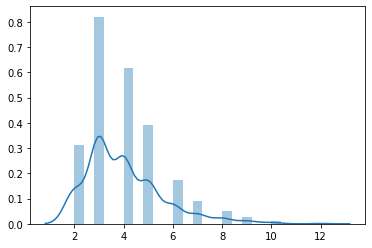

```python
sns.distplot(steps)
```

```python
np.mean(steps)
```

```
4.004
```